# LAB clustering (2 datasets)

65090502417 ปิยพัทธ์ จันทร์ทวี

2025-10-17

```r
library(UniversalCVI)
library(foreign)
library(e1071)
library(mclust)
```

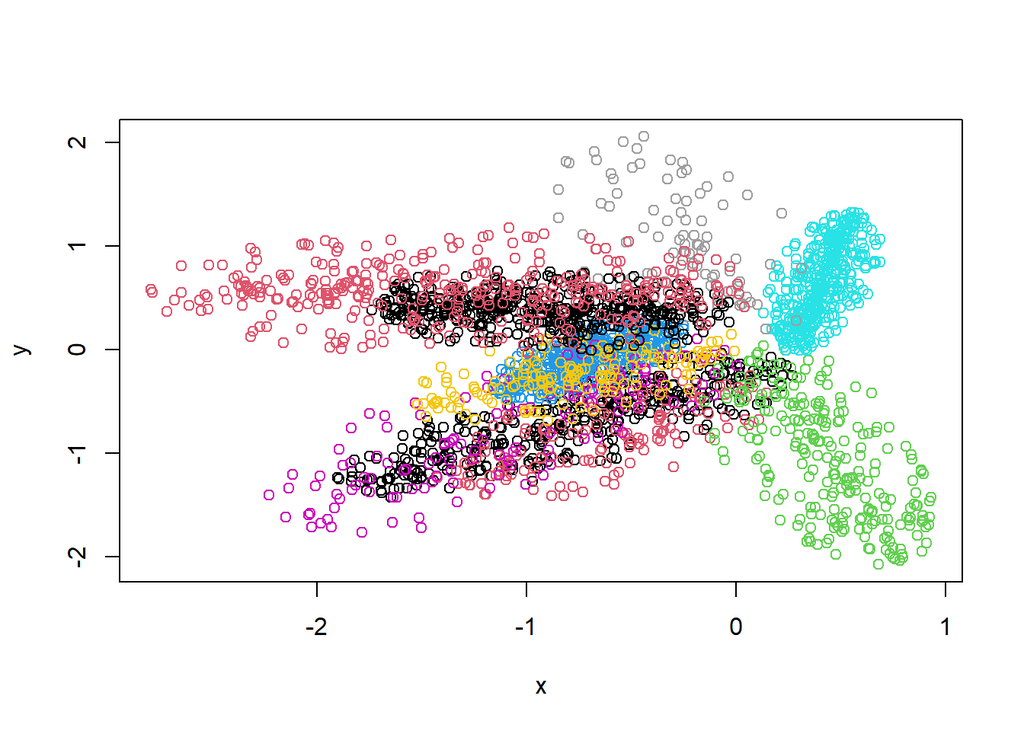

```r
dat1 <- read.arff("data_set_1.arff")
dat2 <- read.arff("data_set_2.arff")

plot(dat1[,1:2], col = dat1$class)
```

```r
table(dat1$class)
```

```
##
##   0   1   2   3   4   5   6   7   8   9
## 369 141 245 457 394 136 161  87 458 348
```

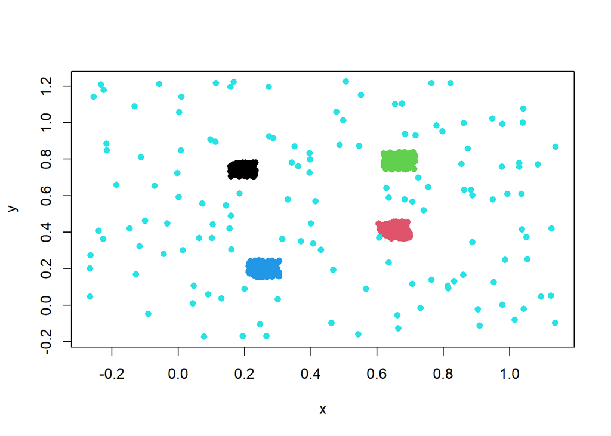

```r
plot(dat2[,1:2], col = dat2$CLASS, pch = 16)
```

```r
table(dat2$CLASS)
```

```
##
##     0     1     2     3 noise
##   111   114   150   109   138
```

### 2 data set (data 1 = 10 กลุ่มทับซ้อน, data 2 = 4 กลุ่ม + กลุ่ม Noise)

### เลือกใช้ index ดังนี้: NCI, CH ,DB ,STR

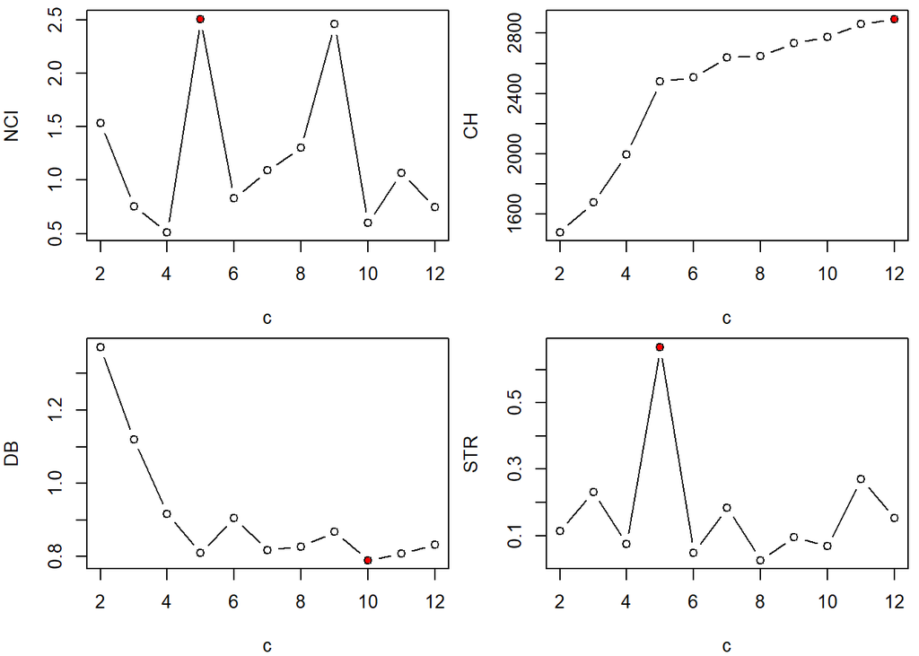

```r
plot_idx(dat1_km_index)
```

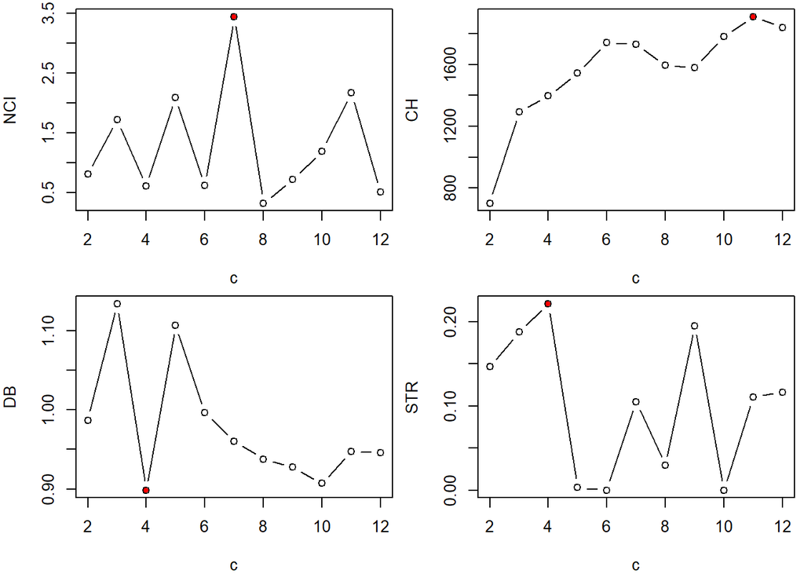

```r
plot_idx(dat1_hcom_index)
```

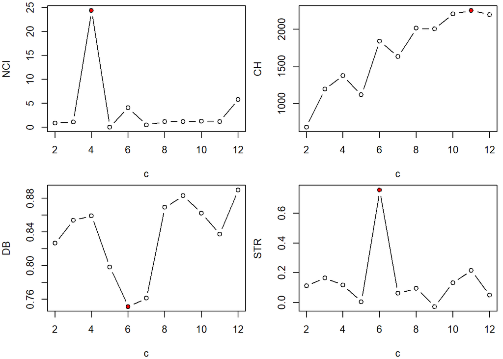

```r
plot_idx(dat1_havg_index)
```

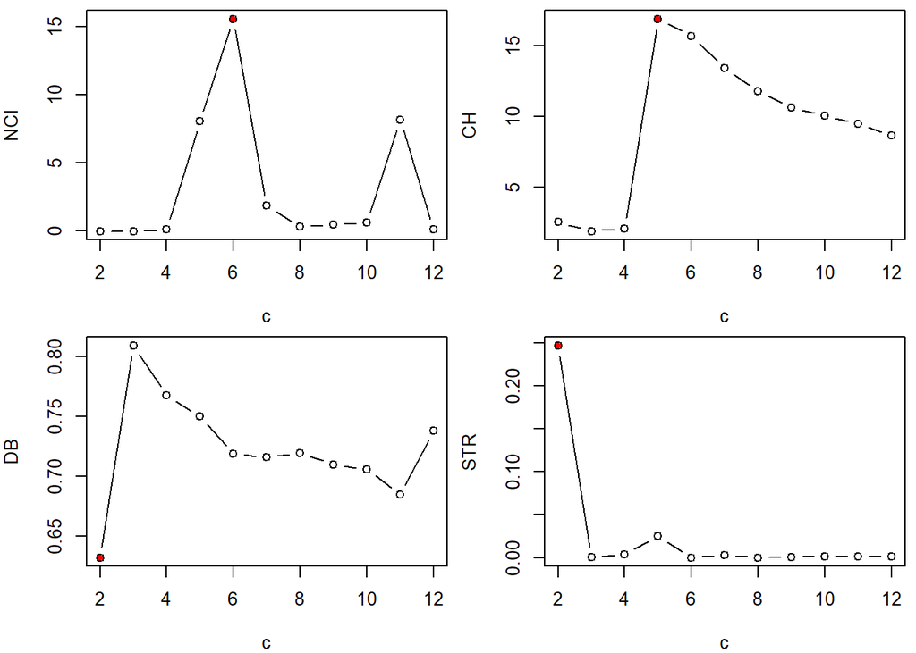

```r
plot_idx(dat1_hsin_index)
```

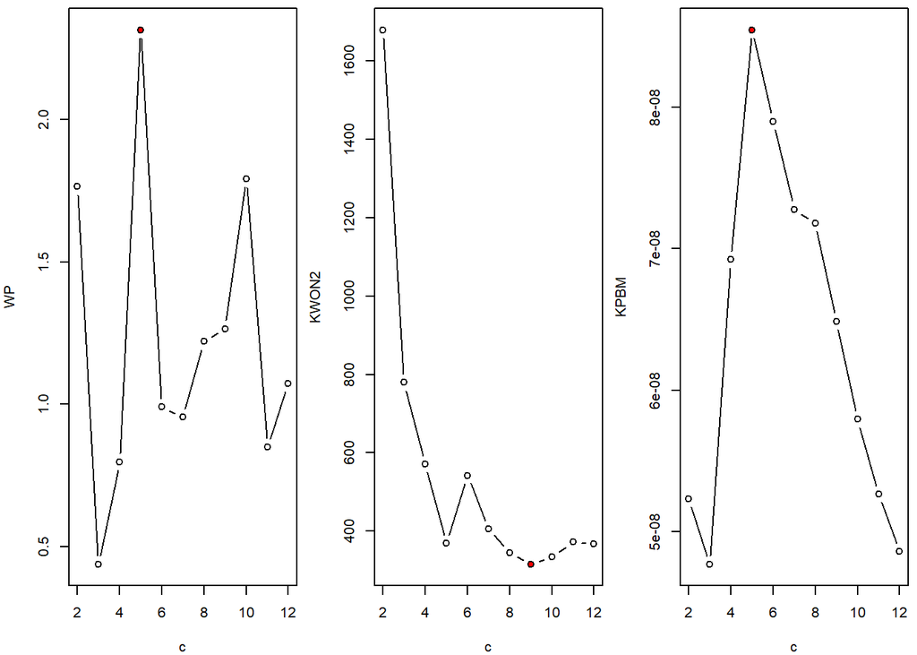

```r
# FzzyCVIs
dat1_fuzzy_index <- FzzyCVIs(dat1[,1:2], cmin = 2, cmax = 12,
                       indexlist = c("WP","KWON2","KPBM"))
dat1_em_index<- FzzyCVIs(dat1[,1:2], cmin = 2, cmax = 12,
                       indexlist = c("WP","KWON2","KPBM"),
                       method = "EM")
plot_idx(dat1_fuzzy_index)
```

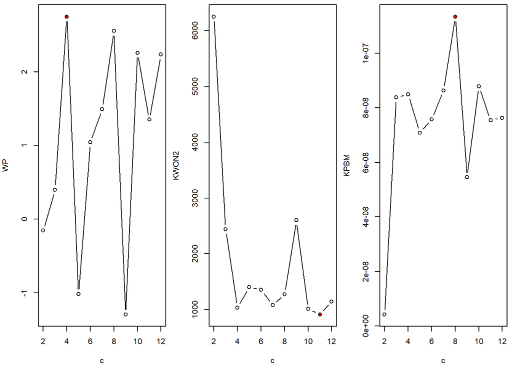

```r
plot_idx(dat1_em_index)
```

## ## Kmeans “DB” index = 10 #

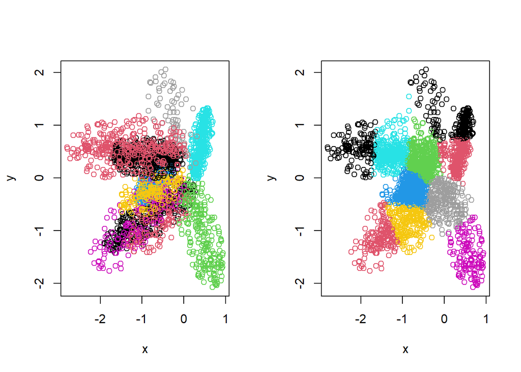

```r
km_d1 <- kmeans(dat1[,1:2], 10)
## Kmeans "DB" index = 10 ##
par(mfrow = c(1,2))
plot(dat1[,1:2], col = dat1$class)
plot(dat1[,1:2], col = km_d1$cluster)
```

```r
par(mfrow = c(1,1))
```

#### จากการใช้ทั้ง Hvalid และ FzzCVIs ในการหาจำนวนกลุ่มที่เหมาะสมกับทุก Method จะได้ว่า index “DB” ใน Hvalid ด้วย Kmeans สามารถจัดกลุ่ม 10 กลุ่ม (ทั้งนี้ทั้งนั้น เป็น 10 กลุ่มที่อาจจะไม่ได้ตรงกับ Class จริงของ Data จึงจะเลือก จำนวนกลุ่มอื่นที่เหมาะสม ได้ว่า ในหลายๆ index บน หลายๆ method ให้ค่า optimal สูงสุดที่ 5 กลุ่ม (จากการที่ data มีแนวโน้มเป็น 5 แฉก)

```r
# kmeans 5 กลุ่ม
km_d1 <- kmeans(dat1[,1:2], 5)
# hcom dat1
hcom_dat1 <- hclust(dist(dat1[,1:2]), method = "complete")
# havg dat1
havg_dat1 <- hclust(dist(dat1[,1:2]), method = "average")
# hsin dat1
hsin_dat1 <- hclust(dist(dat1[,1:2]), method = "single")
# Fuzzy 5 กลุ่ม
fzz_d1 <- cmeans(dat1[, 1:2], centers = 5)
# EM 5 กลุ่ม
em_d1 <- Mclust(dat1[, 1:2], G = 5)
```

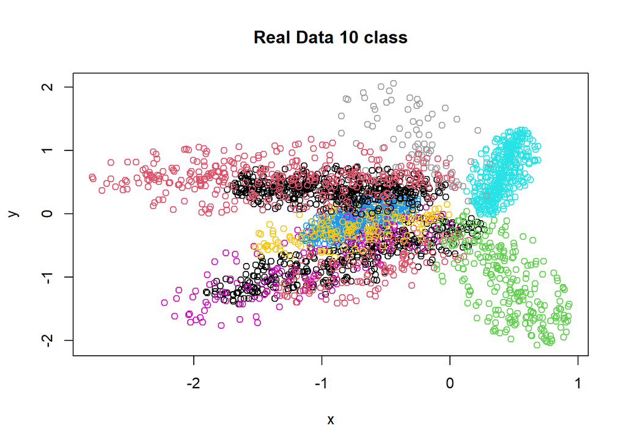

```r
plot(dat1[,1:2], col = dat1$class, main = "Real Data 10 class")
```

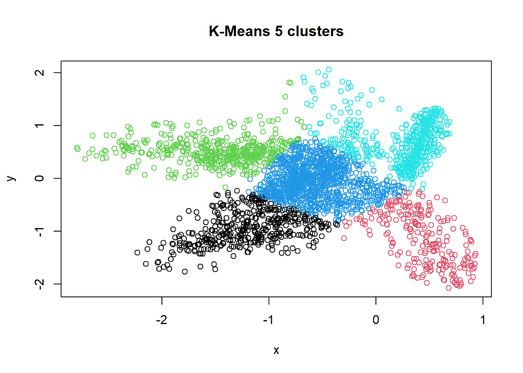

```r
plot(dat1[, 1:2], col = km_d1$cluster, main = "K-Means 5 clusters")
```

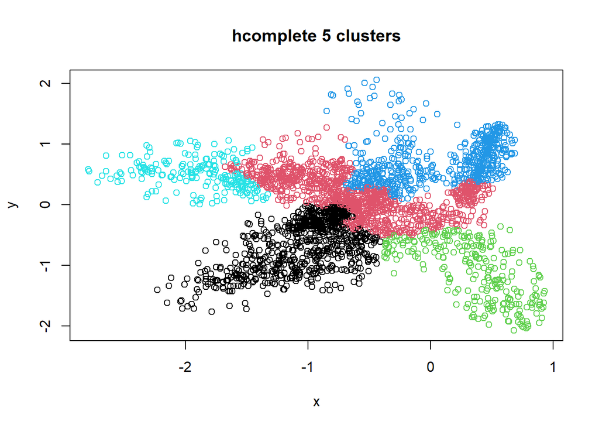

```r
plot(dat1[, 1:2], col = cutree(hcom_dat1, 5), main = "hcomplete 5 clusters")
```

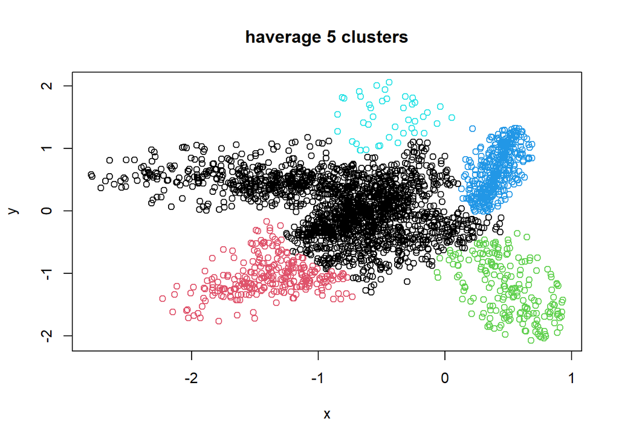

```r
plot(dat1[, 1:2], col = cutree(havg_dat1, 5), main = "haverage 5 clusters")
```

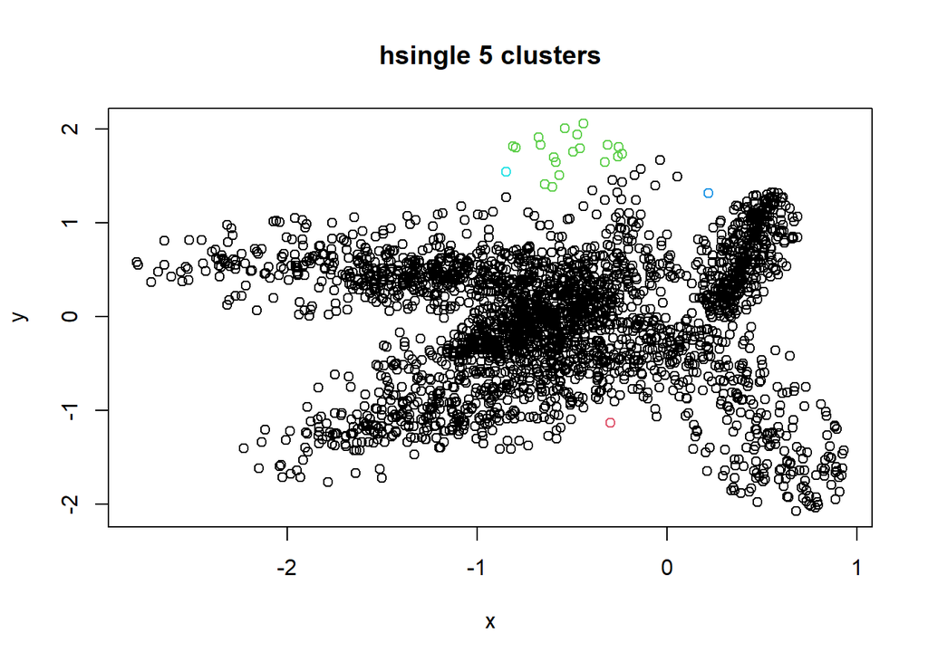

```r
plot(dat1[, 1:2], col = cutree(hsin_dat1, 5), main = "hsingle 5 clusters")
```

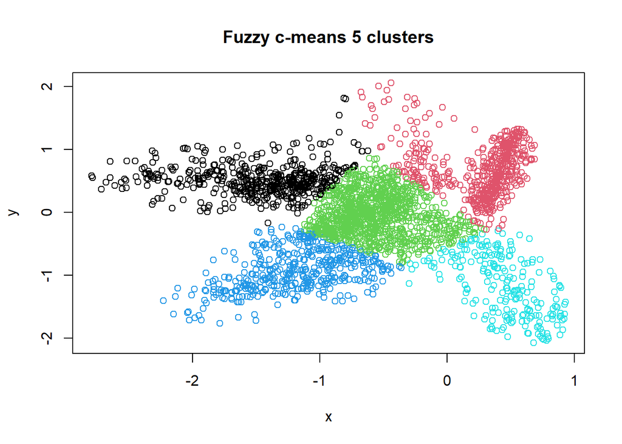

```r
plot(dat1[, 1:2], col = fzz_d1$cluster ,main = "Fuzzy c-means 5 clusters")
```

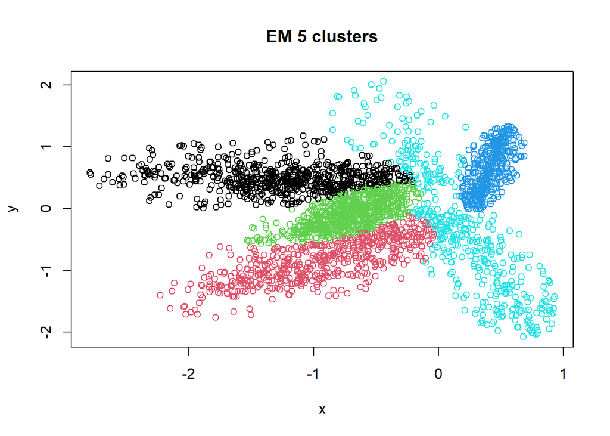

```r
plot(dat1[, 1:2], col = em_d1$classification, main = "EM 5 clusters")
```

# ———————————-

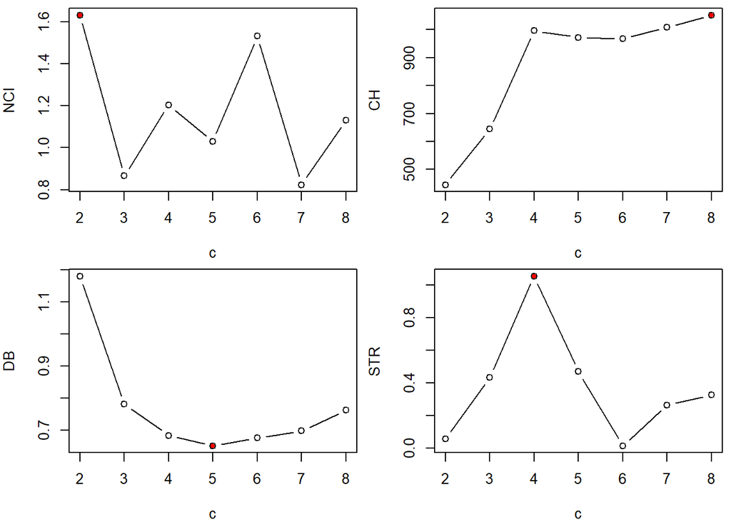

```r
plot_idx(dat2_km_index)
```

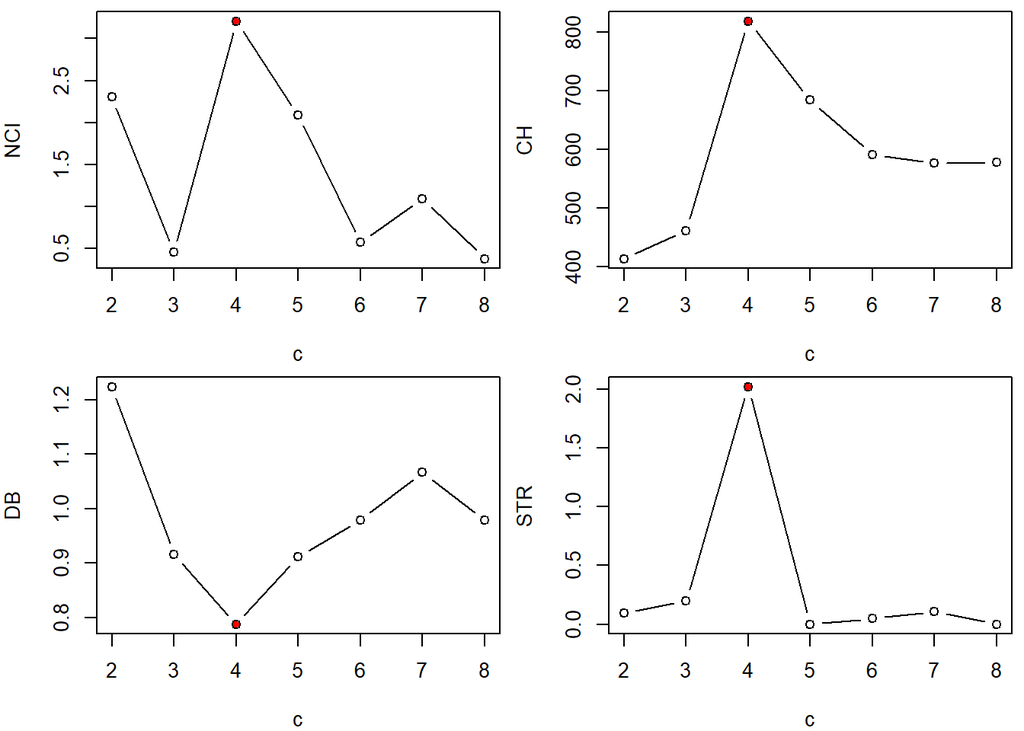

```r
plot_idx(dat2_hcom_index)
```

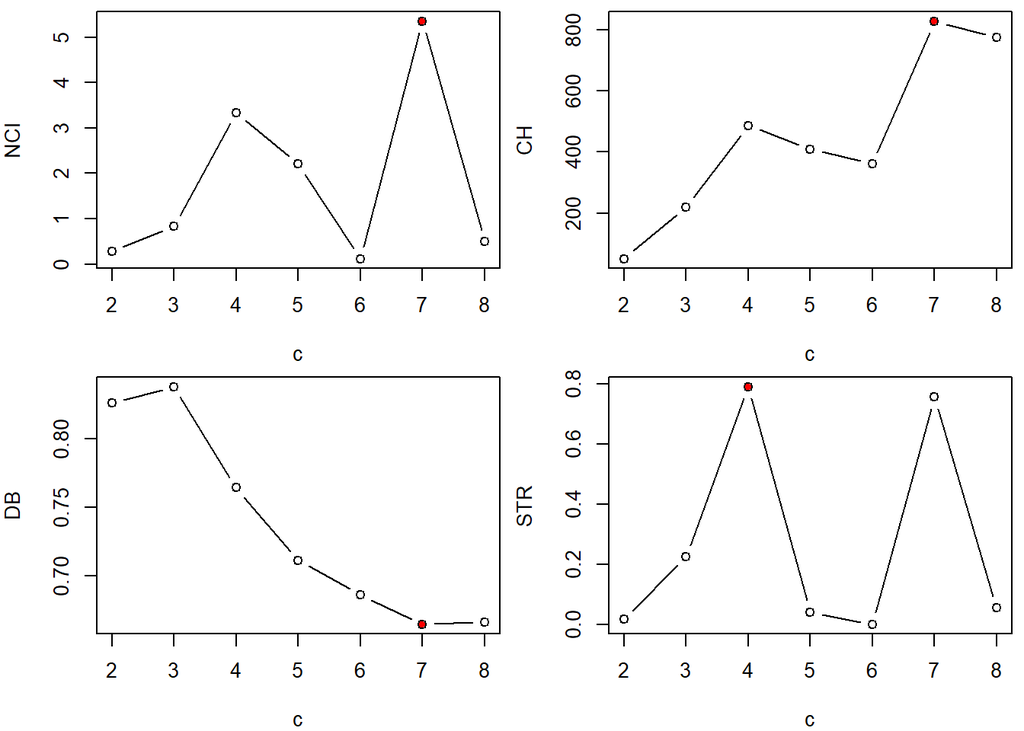

```r
plot_idx(dat2_havg_index)
```

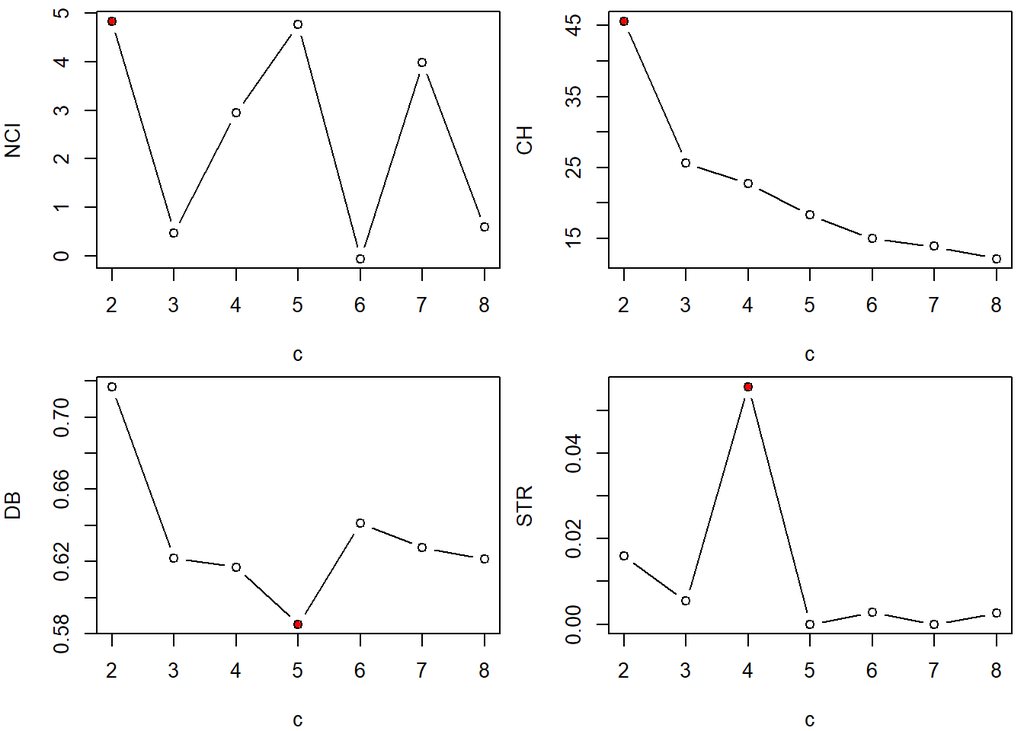

```r
plot_idx(dat2_hsin_index)
```

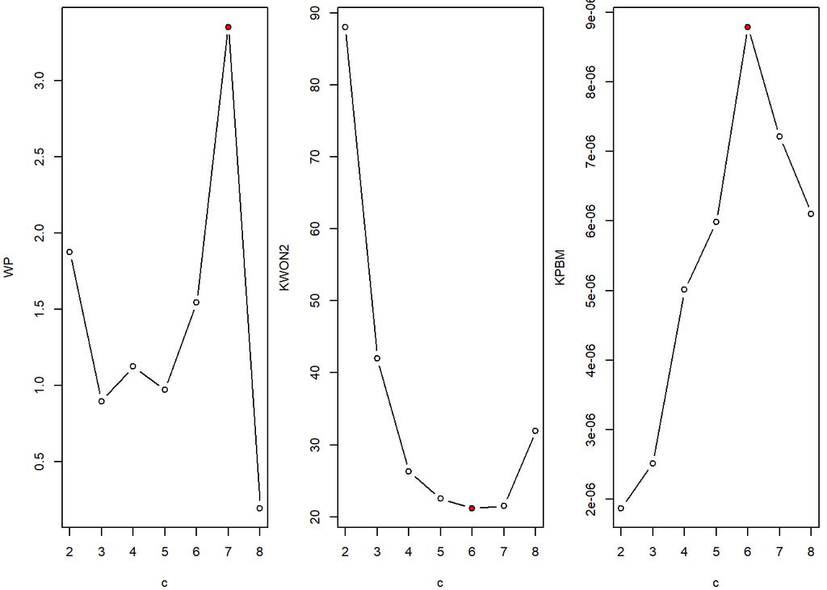

```r
# FzzyCVIs
dat2_fuzzy_index <- FzzyCVIs(dat2[,1:2], cmin = 2, cmax = 8,
                       indexlist = c("WP","KWON2","KPBM"))
dat2_em_index<- FzzyCVIs(dat2[,1:2], cmin = 2, cmax = 8,
                       indexlist = c("WP","KWON2","KPBM"),
                       method = "EM")
plot_idx(dat2_fuzzy_index)
```

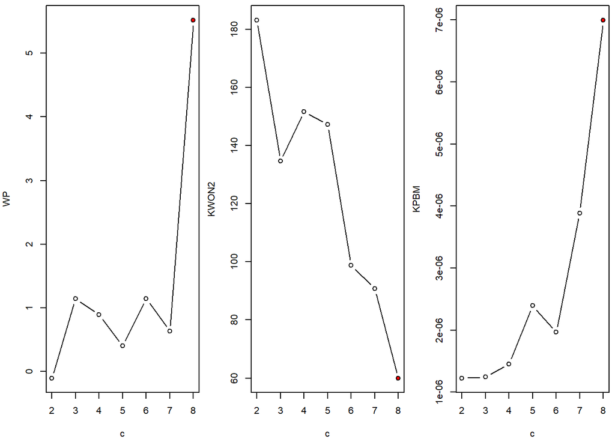

```r
plot_idx(dat2_em_index)
```